# Reproducible Research: Peer Assessment 1

## Loading and preprocessing the data

```r
unzip("repdata-data-activity.zip")
df <- read.csv("activity.csv", sep = ",")
df <- transform(df, date = as.Date(as.character(date), "%Y-%m-%d"))
```

## What is mean total number of steps taken per day?

1. Calculate the total number of steps taken per day

```r
steppd <- tapply(df$steps, df$date, sum, na.rm = TRUE)
print(steppd)
```

```
## 2012-10-01 2012-10-02 2012-10-03 2012-10-04 2012-10-05 2012-10-06
##          0        126      11352      12116      13294      15420
## 2012-10-07 2012-10-08 2012-10-09 2012-10-10 2012-10-11 2012-10-12
##      11015          0      12811       9900      10304      17382
## 2012-10-13 2012-10-14 2012-10-15 2012-10-16 2012-10-17 2012-10-18
##      12426      15098      10139      15084      13452      10056
## 2012-10-19 2012-10-20 2012-10-21 2012-10-22 2012-10-23 2012-10-24
##      11829      10395       8821      13460       8918       8355
## 2012-10-25 2012-10-26 2012-10-27 2012-10-28 2012-10-29 2012-10-30
##       2492       6778      10119      11458       5018       9819
## 2012-10-31 2012-11-01 2012-11-02 2012-11-03 2012-11-04 2012-11-05
##      15414          0      10600      10571          0      10439
## 2012-11-06 2012-11-07 2012-11-08 2012-11-09 2012-11-10 2012-11-11
##       8334      12883       3219          0          0      12608
## 2012-11-12 2012-11-13 2012-11-14 2012-11-15 2012-11-16 2012-11-17
##      10765       7336          0         41       5441      14339
## 2012-11-18 2012-11-19 2012-11-20 2012-11-21 2012-11-22 2012-11-23
##      15110       8841       4472      12787      20427      21194
## 2012-11-24 2012-11-25 2012-11-26 2012-11-27 2012-11-28 2012-11-29
##      14478      11834      11162      13646      10183       7047
## 2012-11-30
##          0
```

2. If you do not understand the difference between a histogram and a barplot, research the difference between them. Make a histogram of the total number of steps taken each day.

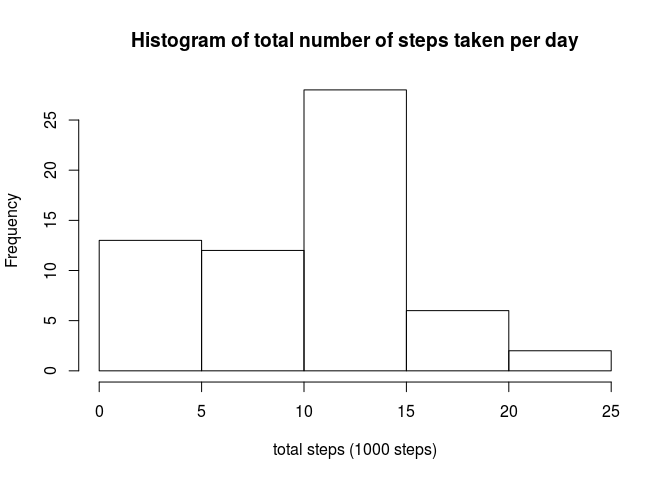

```r
hist(steppd/1000, main = paste("Histogram of" , "total number of steps taken per day"), xlab = "total steps (1000 steps)")
```

3. Calculate and report the mean and median of the total number of steps taken per day.

```r
stepm <- mean(steppd)
stepmd <- median(steppd)
```

The mean of the total number of steps taken per day is **9354.2295082**, and the median of the total number of steps taken per day is **10395**.

## What is the average daily activity pattern?

1. Make a time series plot (i.e. type = “l”) of the 5-minute interval (x-axis) and the average number of steps taken, averaged across all days (y-axis).

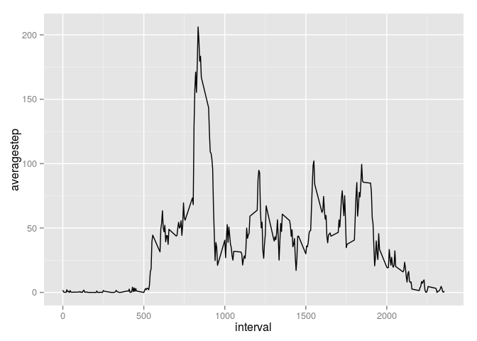

```r
library(ggplot2)
# qplot(interval, steps, data = df, color = date, geom = "path")
df2 <- data.frame(averagestep = tapply(df$steps, df$interval, mean, na.rm = TRUE), interval = df[df$date == "2012-10-01","interval"])
qplot(interval, averagestep, data = df2, geom = "path")
```

```r
intv <- df2[max(df2$averagestep),]
```

## Imputing missing values

1. Calculate and report the total number of missing values in the dataset (i.e. the total number of rows with NAs)

```r
#summary(df$steps)
#summary(df$interval)
#summary(as.factor(df$date))
#table(df$steps %in% NA)
table(is.na(df))
```

```
##
## FALSE  TRUE
## 50400  2304
```

```r
colSums(is.na(df))
```

```
##    steps     date interval
##     2304        0        0
```

There is **2304** missing values in the dataset.

2. Devise a strategy for filling in all of the missing values in the dataset. The strategy does not need to be sophisticated. For example, you could use the mean/median for that day, or the mean for that 5-minute interval, etc.

*The missing value will be filled by the mean of that 5-minute interval across the days.*

3. Create a new dataset that is equal to the original dataset but with the missing data filled in.

```r
# tapply(is.na(df$steps), df$date, sum)  #check the distribution of NAs
# df2$averagestep is the mean of that 5-minute interval across the days
dfnona <- df
for (i in seq_along(df2$interval)){
      dfnona[which(is.na(dfnona$steps) & dfnona$interval == df2[i, "interval"]), "steps"] <- df2[i, "averagestep"]
}
```

The new generated data frame without missing value is *dfnona*.

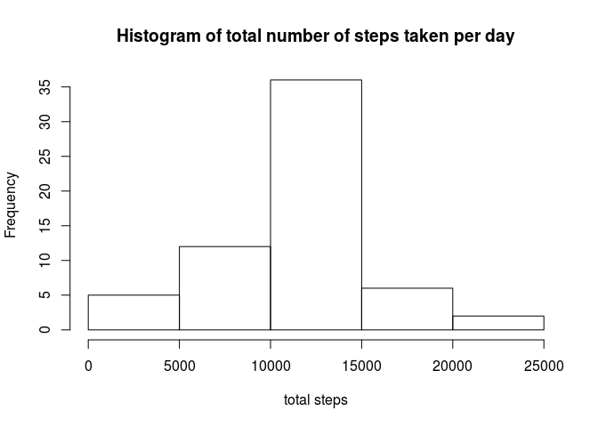

```r
steppdnona <- tapply(dfnona$steps, dfnona$date, sum, na.rm = TRUE)
hist(steppdnona, main = paste("Histogram of" , "total number of steps taken per day"), xlab = "total steps")
```

```r
stepmnona <- mean(steppdnona)
stepmdnona <- median(steppdnona) # floor() take the integer part
```

## Are there differences in activity patterns between weekdays and weekends?

1. Create a new factor variable in the dataset with two levels – “weekday” and “weekend” indicating whether a given date is a weekday or weekend day.

```r
weekday <- c("Monday", "Tuesday", "Wednesday", "Thursday", "Friday")
weekend <- c("Saturday", "Sunday")
dfnona$weekdays <- weekdays(dfnona$date)
dfnona[dfnona$weekdays %in% weekday, "weekdays"] <- "weekday"
dfnona[dfnona$weekdays %in% weekend, "weekdays"] <- "weekend"
dfnona$weekdays <- factor(dfnona$weekdays, levels = c("weekday", "weekend"))
# dfnona$weekday <- as.factor(dfnona$weekday)
```

The new factor variable is **weekdays**.

2. Make a panel plot containing a time series plot (i.e. type = “l”) of the 5-minute interval (x-axis) and the average number of steps taken, averaged across all weekday days or weekend days (y-axis). See the README file in the GitHub repository to see an example of what this plot should look like using simulated data.

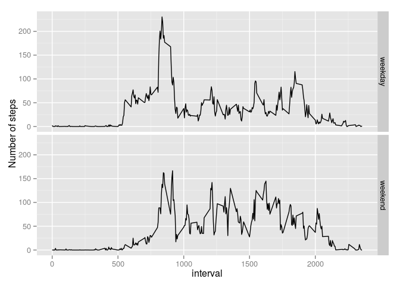

```r
library(dplyr)
df3 <- aggregate(dfnona, by = list(dfnona$weekdays, dfnona$interval), FUN = "mean")
# df3 <- rename(df3, weekdayfac = Group.1)
# df3  %>% select(weekdayfac = Group.1, steps, interval)
# dfnona %>%  aggregate(by = list(dfnona$weekdays, dfnona$interval), FUN = "mean")
#    %>% select(weekdayfac = Group.1, steps, interval)
df4 <- select(df3, weekdayfac = Group.1, steps, interval)
qplot(interval, steps, data = df4, facets = weekdayfac ~ ., geom = "path", xlab = "interval", ylab = "Number of steps")
```